# Data Dictionary - Emory QTM Fall 2022

Tony Chen Gu, Nancy Chen

2022-11-14

## Tony - 2022 Fall

```r
data = read.csv("export_dataframe_stage2.csv")
```

### air_tmep

- record the temperature in Celsius
- 60 percent of data is not NA and 0.5% of them shows a temperature over 40 degrees Celsius (104 F)

```r
summary(data$air_temp)
```

```
##     Min.  1st Qu.   Median     Mean  3rd Qu.     Max.     NA's
##    -9.00    14.50    21.00    20.65    25.60 13143.00    24253
```

```r
num_obs = length(data$air_temp)
num_NA = sum(is.na(data$air_temp))
paste("number of NA is ",num_NA)
```

```
## [1] "number of NA is  24253"
```

```r
paste("numer of valid data is ",num_obs - num_NA)
```

```
## [1] "numer of valid data is  35345"
```

```r
paste("percent of NA is",num_NA/ num_obs)
```

```
## [1] "percent of NA is 0.406943186012953"
```

```r
paste("percent of valid data is",(num_obs - num_NA) / num_obs)
```

```
## [1] "percent of valid data is 0.593056813987047"
```

Min to 3rd Quantile looks good, the Max value looks weird.

```r
over40 = sum(data$air_temp > 40, na.rm = TRUE)
paste("There are", over40, "of recording shows a temperature over 40 degrees Celcius (104 F). It's", over40/(num_obs - num_NA), "% of valid data.")
```

```
## [1] "There are 187 of recording shows a temperature over 40 degrees Celcius (104 F). It's 0.00529070589899561 % of valid data."
```

### air_tmeperature

- record the temperature in Celsius
- shows more NA than air_temp (60% of data is NA)
- 0.3% of valid data is higher than 40 degrees Celsius (104 F)

```r
summary(data$air_temperature)
```

```
##     Min.  1st Qu.   Median     Mean  3rd Qu.     Max.     NA's
##    -9.00    14.09    20.50    20.50    25.50 13143.00    35934
```

```r
num_obs = length(data$air_temperature)
num_NA = sum(is.na(data$air_temperature))
paste("number of NA is ",num_NA)
```

```
## [1] "number of NA is  35934"
```

```r
paste("numer of valid data is ",num_obs - num_NA)
```

```
## [1] "numer of valid data is  23664"
```

```r
paste("percent of NA is",num_NA/ num_obs)
```

```
## [1] "percent of NA is 0.602939695962952"
```

```r
paste("percent of valid data is",(num_obs - num_NA) / num_obs)
```

```
## [1] "percent of valid data is 0.397060304037048"
```

Min to 3rd Quantile looks good, the Max value looks weird.

```r
over40 = sum(data$air_temperature > 40, na.rm = TRUE)
paste("There are", over40, "of recording shows a temperature over 40 degrees Celcius (104 F). It's", over40/(num_obs - num_NA), "% of valid data.")
```

```
## [1] "There are 91 of recording shows a temperature over 40 degrees Celcius (104 F). It's 0.00384550371872887 % of valid data."
```

### min_temp

```r
summary(data$min_temp)
```

```
##    Min. 1st Qu.  Median    Mean 3rd Qu.    Max.    NA's
##    0.00   34.10   34.60   34.34   35.00   95.00   52188
```

```r
num_obs = length(data$min_temp)
num_NA = sum(is.na(data$min_temp))
paste("number of NA is ",num_NA)
```

```
## [1] "number of NA is  52188"
```

```r
paste("numer of valid data is ",num_obs - num_NA)
```

```
## [1] "numer of valid data is  7410"
```

```r
paste("percent of NA is",num_NA/ num_obs)
```

```
## [1] "percent of NA is 0.875666968690225"
```

```r
paste("percent of valid data is",(num_obs - num_NA) / num_obs)
```

```
## [1] "percent of valid data is 0.124333031309775"
```

min_temp of 95 is defiantly abnormal

```r
over35 = sum(data$air_temperature > 35, na.rm = TRUE)
paste("There are", over35, "of recording shows a temperature over 35 degree Celcius (95 F). It's", over35/(num_obs - num_NA), "% of valid data.")
```

```
## [1] "There are 212 of recording shows a temperature over 35 degree Celcius (95 F). It's 0.0286099865047233 % of valid data."
```

### max temp

```r
summary(data$max_temp)
```

```
##    Min. 1st Qu.  Median    Mean 3rd Qu.    Max.    NA's
##    0.00   35.00   35.50   35.25   35.90  355.00   52180
```

```r
num_obs = length(data$max_temp)
num_NA = sum(is.na(data$max_temp))
paste("number of NA is ",num_NA)
```

```
## [1] "number of NA is  52180"
```

```r
paste("numer of valid data is ",num_obs - num_NA)
```

```
## [1] "numer of valid data is  7418"
```

```r
paste("percent of NA is",num_NA/ num_obs)
```

```
## [1] "percent of NA is 0.875532735997852"
```

```r
paste("percent of valid data is",(num_obs - num_NA) / num_obs)
```

```
## [1] "percent of valid data is 0.124467264002148"
```

Max_temp over 355 is weird.

```r
over40 = sum(data$air_temperature > 40, na.rm = TRUE)
paste("There are", over40, "of recording shows a temperature over 40 degrees Celcius (104 F). It's", over40/(num_obs - num_NA), "% of valid data.")
```

```
## [1] "There are 91 of recording shows a temperature over 40 degrees Celcius (104 F). It's 0.0122674575357239 % of valid data."
```

### water_temp

- record the water temperature in Celsius
- about 40% of the data are NA
- has abnormal data like 110 degree, only 0.3% of data is over 40 degree

```r
summary(data$water_temp)
```

```
##    Min. 1st Qu.  Median    Mean 3rd Qu.    Max.    NA's
##   -3.00   12.00   17.30   17.47   22.50  110.00   24171
```

```r
num_obs = length(data$water_temp)
num_NA = sum(is.na(data$water_temp))
paste("number of NA is ",num_NA)
```

```
## [1] "number of NA is  24171"
```

```r
paste("numer of valid data is ",num_obs - num_NA)
```

```
## [1] "numer of valid data is  35427"
```

```r
paste("percent of NA is",num_NA/ num_obs)
```

```
## [1] "percent of NA is 0.405567300916138"
```

```r
paste("percent of valid data is",(num_obs - num_NA) / num_obs)
```

```
## [1] "percent of valid data is 0.594432699083862"
```

water temperature over 100 degree is too high. Look more into its data.

```r
over40 = sum(data$water_temp > 40, na.rm = TRUE)
paste("There are", over40, "of recording shows a water temperature over 40 degrees Celcius (104 F). It's", over40/(num_obs - num_NA), "% of valid data.")
```

```
## [1] "There are 102 of recording shows a water temperature over 40 degrees Celcius (104 F). It's 0.00287915996274028 % of valid data."
```

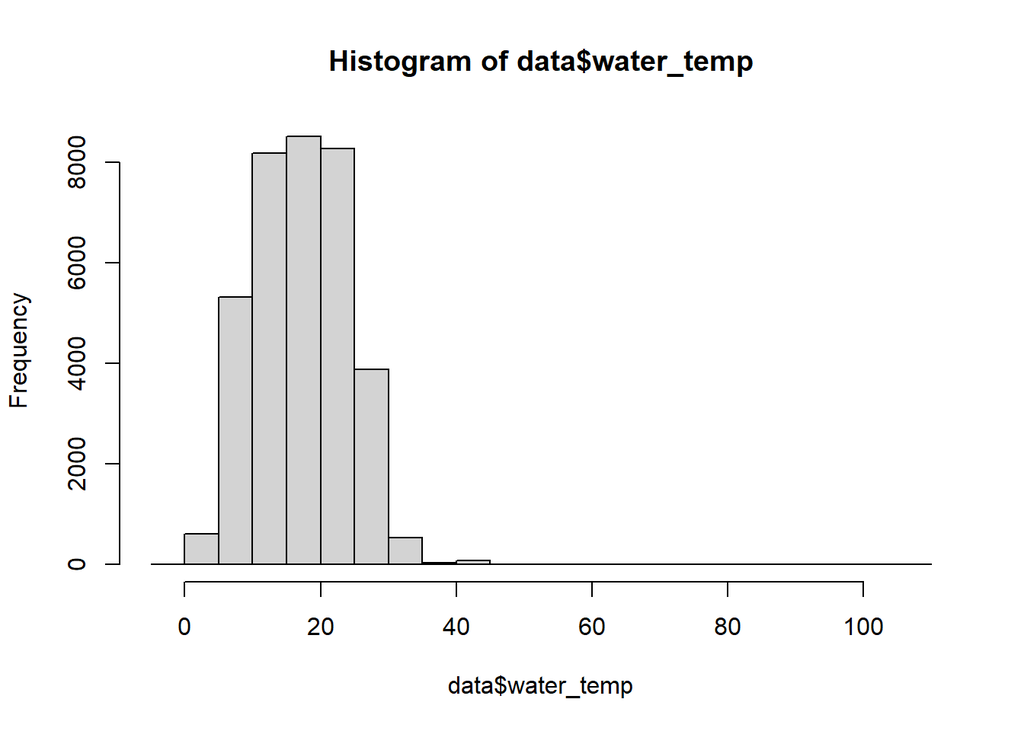

```r
hist(data$water_temp)
```

## Nancy - 2022 Fall

import dataset:

```r
stage2<-read.csv("export_dataframe_stage2.csv")
```

### stream

status of the stream

```r
# display unique values
unique(stage2$stream)
```

```
## [1] ""            "rocky"       "muddy"       "muddy;rocky" "27"
## [6] "26.67"       "23"          "8.8"         "10.5"
```

```r
# counting for the number of null/error values
count_empty = 0
count_error = 0
for (i in 1:length(stage2$stream)){
  if (stage2$stream[i] == ""){
    count_empty = count_empty +1
  }
  if (stage2$stream[i] == "27" |stage2$stream[i] == "26.67" | stage2$stream[i] == "23" |stage2$stream[i] == "8.8" | stage2$stream[i] == "10.5" ){
    count_error = count_error + 1
  }
}

paste0("count_empty: ", count_empty)
```

```
## [1] "count_empty: 59177"
```

```r
paste0("count_error: ", count_error)
```

```
## [1] "count_error: 5"
```

### method

method used to measure the values

- 2 distinct method: `kick`, `d-frame`
  - **kick**: Measuring the abundance of macroinvertebrates (small aquatic animals) in the river by kicking up gravels. Unpolluted river will have a higher diversity
  - **d-frame**: sweeping or jabbing nets into appropriate habitats to collect organisms from the sediment and water column
- All strings
- 59325 empty values, 4 numeric values (most likely to be input errors)

```r
# display unique values
unique(stage2$method)
```

```
## [1] ""        "kick"    "d-frame" "22.2"    "21.11"   "22.6"    "12.7"
```

```r
# counting null/error values
count_empty = 0
count_error = 0
for (i in 1:length(stage2$method)){
  if (stage2$method[i] == ""){
    count_empty = count_empty +1
  }
  if (stage2$method[i] == "22.2" |stage2$method[i] == "21.11" | stage2$method[i] == "22.6" |stage2$method[i] == "12.7"){
    count_error = count_error + 1
  }
}

#printing
paste0("count_empty: ", count_empty)
```

```
## [1] "count_empty: 59325"
```

```r
paste0("count_error: ", count_error)
```

```
## [1] "count_error: 4"
```

### wqi

**Water quality limited segment**: any stream segment where the water quality does not or will not meet applicable water quality standards

- 34 distinct values
- 59084 NA values
- All integers

```r
# display unique values
unique(stage2$wqi)
```

```
##  [1]  1 NA 22 19 24 14 12 21  8  9  5 13 23 17 11 18  7  4 15 26 20 10 25  6  2
## [26] 16 31 30  3 28  0 27 29 32 42
```

```r
# counting null values
count_NA = 0
for (i in 1:length(stage2$wqi)){
  if (is.na(stage2$wqi[i])){
    count_NA = count_NA +1
  }
}

# printing
paste0("count_NA: ", count_NA)
```

```
## [1] "count_NA: 59084"
```

### habitat

natural environment around the stream

- 48 distinct habitats
- All strings
- 59144 empty values

```r
# display a few unique values
head(unique(stage2$habitat))
```

```
## [1] ""                            "riffle;leaf pack;vegetated;"
## [3] "leaf pack;sand;vegetated;"   "riffle;leaf pack;"
## [5] "leaf pack;vegetated;"        "leaf pack;silt;vegetated;"
```

```r
# count the number of distinct values
length(unique(stage2$habitat))
```

```
## [1] 49
```

```r
# count empty values
count_empty = 0
for (i in 1:length(stage2$habitat)){
  if (stage2$habitat[i] == ""){
    count_empty = count_empty +1
  }
}

# printing
paste0("count_empty: ", count_empty)
```

```
## [1] "count_empty: 59144"
```

### chem_detail_rid

chemical details of the stream

- 58728 distinct values
- All numeric integers
- No null values

```r
# display a few distinct values
head(unique(stage2$chem_detail_rid))
```

```
## [1]  8785  8792  9940 10654 10662 11027
```

```r
# number of distinct values
length(unique(stage2$chem_detail_rid))
```

```
## [1] 58728
```

```r
# counting number of empty values (check all possible way of null values inputs)
count_empty = 0
for (i in 1:length(stage2$chem_detail_rid)){
  if (stage2$chem_detail_rid[i] == "NULL" | stage2$chem_detail_rid[i] == "" | is.na(stage2$chem_detail_rid[i])){
    count_empty = count_empty +1
  }
}

# printing
paste0("count_empty: ", count_empty)
```

```
## [1] "count_empty: 0"
```